# Unit 3 Walkthrough: School Leader Selection Mechanism

ECI 589 Social Network Analysis and Education

Dr. Shaun Kellogg

July 21, 2021

# 1. PREPARE

For the Unit 3 Walkthrough: School Leader Selection Mechanisms we will once again visit research conducted by Alan Daly and colleagues as we attempt to replicate some of the analyses described in Chapter 9: Network Data and Statistical Models from Social Network Analysis and Education (Carolan 2014). In this walkthrough we’ll revisit and and then move beyond the visual and mathematical descriptions of networks explored so far to uncover generative processes, or mechanisms, that attempt to explain how school leaders select peers for collaboration or confidential exchanges.

More specifically, this walkthrough will cover the following topics pertaining to each data-intensive workflow process:

1. **Prepare**: Prior to analysis, we’ll take a look at the context from which our data came, formulate some research questions, and get introduced the {statnet} R package for ERGMs.
2. **Wrangle**: In section 2 we will learn how to work with matrices, how to dichotomize matrices, and how to convert matrices into more workable formats like our familiar edge-list.
3. **Explore**: In section 3, we once again use the {tidygraph} package and the companion {ggraph} package to calculate basic summary stats for our network and will try to replicate and ideally improve upon the sociogram in our course text.
4. **Model**: We wrap up our analysis in Section 4 by introducing exponential random graph modules used in Chapter 9 of Carolan (2014), learn to check how well our model “fits our data” and examine diagnostics that might indicate our model has issues.
5. **Communicate**: We briefly reflect on our walkthrough in preparation for our independent analysis next week.

## 1a. Review the Research

Recall from [Social Network Analysis and Education: Theory, Methods & Applications](https://methods.sagepub.com/book/social-network-analysis-and-education) that Carolan (2014) made the following distinctions between mathematical and statistical approaches to social network analysis:

1. **Mathematical approaches** focus on what network of actors “looks like” by describing the network using sociograms and/or network measures such as reciprocity, centrality, and density. However, these approaches “tend to regard the measured relationships and their strengths as accurately reflecting the real, final, or equilibrium status of the network.”
2. **Statistical approaches**, or statistical inference, on the other hand, focuses on “assessing the reproducibility or likelihood of an observed pattern” with the goal of explaining and ultimately predicting network structures and outcomes.

For Unit 3, we move beyond previous “mathematical approaches” used so far and explore the use of ERGMs as a “statistical approach” to network analysis. Specifically, we will try to replicate the P* models used in Chapter 9 of Carolan (2014) in order to test hypotheses about individual and network characteristics that may explain who school leaders select for collaboration and confidential exchanges.

### Research Questions

For this walkthrough, we will be using school leadership data were collected at two school districts over 3 consecutive years that was used to answer the following research questions:

1. Is there a relationship between the frequency of collaboration between school leaders and how often they turn to each other to discuss issues of a confidential nature?
2. Do school leaders prefer to collaborate with those with whom they have collaborated in the past, or is there some other reason?
3. Does gender or some other individual attribute predicts confidential exchanges between school leaders, or does some previous relation have a stronger effect?
4. Does collaboration between leaders explain one’s level of trust in one’s administrative colleagues?
5. Can we distinguish among different groups of school leaders based on how frequently they collaborate, and if so, are these groupings related to the level at which they work (school versus district)?

### Data Collection

For each consecutive year, school district leaders were invited to complete a survey that collected individual:

- **Demographic information** (e.g., gender, ethnicity, marital status, age, years of experiences),
- **Network relationships types** (e.g., collaboration, confidential, energy, expertise, support you approach, support approach you, work-related issues, input, recognition, best practices, and innovation), efficacy, and trusting relationships.
- **Frequency of interactions** they have with those nominated individuals on a four-point frequency scale ranging from 1 (the least frequent) to 4 (1–2 times a week).
- **Leadership efficacy** items were designed based on the Principal Efficacy Scale used in Daly et al. (2011) and Tschannen-Moran and Gareis’s (2004) studies. The efficacy scale includes 18 items rated on a 9-point Likert scale ranging from 1 (None at all) to 9 (A great deal).
- **Trust** scale contains eight items rated on a 7-point Likert scale ranging from 1 (Strongly disagree) to 7 (Strongly agree) modified from Tschannen-Moran and Hoy (2003)

### Analyses

Two modeling techniques unique to network analysis and demonstrated in Chapter 9 are the quadratic assignment procedure (QAP) and Exponential Random Graph Models (ERGM):

- **QAP/MR**: The quadratic assignment procedure (QAP) developed by Hubert (1987) and Krackhardt (1987b) tests the null hypothesis of no correlation between the two networks and adjusts for this dependence between networks by repeatedly permuting the order of rows and columns of one of the networks while keeping the other network intact. The QAP is based on regression models and permutation tests for valued (i.e., continuous) relational variables.
- **P1 and P* (P-Star)**: Both of these models are some of the first to make use of the ERGM, which provides a basis for comparing whether a network’s observed structural properties occur more frequently than you could expect from chance alone. ERGMs can be used to model ties in complete networks but do so in a manner that explains the presence (or absence) of ties as a function of individual-and/or network-level characteristics. While QAP and MR-QAP procedures control for network structure through permutations, these ERGMs attempt to explain it.

## 1b. Key Findings

In response to research questions 1 & 2 from above, Carolyn reported that “while collaboration in year 1 does not significantly predict collaboration in year 3, confidential exchanges in year 1 does” and suggested that “collaboration among school leaders provides an important foundation for more sensitive, perhaps even deeper, relations (e.g., confidential exchanges) at a later point in time.”

### **👉 Your Turn** **⤵**

For our Unit 3 Walkthrough, we focus specifically on generative processes, or micro-level mechanisms, the might help explain who school leaders select to collaborate with or engage in confidential exchanges. Review Chapter 9 of SNA and Education and report out on the findings from the ERGM analysis in response to research question 3 below:

3. **Does gender or some other individual attribute predicts confidential exchanges between school leaders, or does some previous relation have a stronger effect?**
   - YOUR RESPONSE HERE

Based on what you know about networks and the context so far, what other specific question(s) might the data and analyses described allow you to address. For example, the concept of homophily, or the tendency for people to seek out or form ties to those who are similar to themselves, was introduced in our readings and hypotheses about homophily can easily be tested using using ERGMs:

- YOUR RESPONSE HERE

Save this question for later as you’ll have a chance to test it by the end of this walkthrough.

## **1c.** Load Libraries

Recall that **packages**, or libraries, are shareable collections of R code that can contain functions, data, and/or documentation and extend the functionality of R. You can always check to see which packages have already been installed and loaded into RStudio Cloud by looking at the the Files, Plots, & Packages Pane in the lower right hand corner.

Let’s go ahead and load the packages from Units 1 & 2 since we’ll be using them again in this walkthrough:

```r
library(readxl)
library(tidyverse)
```

```r
library(igraph)
library(tidygraph)
library(ggraph)
```

#### statnet 📦

[figure not shown]

Similar to the collection of packages contained in the {tidyverse} package, the Statnet Team (Pavel N. Krivitsky et al. 2003-2020) has developed a suite of R packages for the management, exploration, statistical analysis, simulation and vizualization of network data. The statistical modeling framework used in {statnet} relies on Exponential-family Random Graph Models (ERGMs).

As noted in the [statnet tutorial](http://statnet.org/Workshops/ergm_tutorial.html#The_statnet_Project) by the same authors, the exponential-family random graph models (ERGMs) are a general class of models based in exponential-family theory for specifying the probability distribution for a set of random graphs or networks. Within this framework, one can—among other tasks:

1. Define a model for a network that includes covariates representing features like homophily, mutuality, triad effects, and a wide range of other structural features of interest;
2. Obtain maximum-likehood estimates for the parameters of the specified model for a given data set;
3. Test individual coefficients, assess models for convergence and goodness-of-fit and perform various types of model comparison; and
4. Simulate new networks from the underlying probability distribution implied by the fitted model.

Let’s load the {statnet} package that we’ll be using in the Model section of our walkthrough for bullets 1-3 above:

```r
library(statnet)
```

# 2. WRANGLE

For our data wrangling this week, we’ll focus on working with network data stored as an adjacency matrix. Our primary goals for this section are learning how to:

1. **Import Data**. In this section, we use the {readxl} package from the tidyverse to read in a matrix and node .
2. **Dichotomize a Matrix**. As described in Chapter 9, we’ll recode our edge values to 1s and 0s changing our valued matrix to a binary matrix.
3. **Create Network Graph**. Finally, we’ll convert our matrix to an edge-list and store both our edges and node attributes as a network igraph object in preparation for analysis.

## 2a. Import Data

One of our primary goals is to replicate the ERGM analysis from Chapter 9: Network Data and Statistical Models (Carolan 2014). Specifically, we’ll aim to reproduce the results from **Table 9.4. Results of P1 and P*Analyses for the Dichotomized and Directed School Leaders Confidential Exchanges Network Year 3.**

To do so, we’ll need to import two Excel files from the Social Network Analysis and Education companion site. The first file contains our edges stored as a square matrix (more on this later) and the second file is a standard rectangular data frame that contains attributes for each node, i.e. school leaders. These files are included in the data folder of your R Studio project. A description of each file from the companion website and a direct link to the file are included below:

1. [**School Leaders Data Chapter 9_d.**](https://studysites-sagepub-com.prox.lib.ncsu.edu/carolan/study/materials/datasets/99472_ds10.xls) This adjacency matrix reports on “confidential help” ties among 43 school leaders in year 3 of a three-year study. This is a directed valued (weighted) network measured on five-point scale ranging from 0 to 4, with higher values indicating more frequent collaborations (1–2 times/week). These data are used throughout Chapter 9.
2. [**School Leaders Data Chapter 9_e.**](https://studysites-sagepub-com.prox.lib.ncsu.edu/carolan/study/materials/datasets/99472_ds11.xlsx) This rectangular matrix consists of four attribute vectors for 43 school leaders. Following the first ID column, the matrix includes an efficacy score, trust score, and indicators for whether one works at the district-level and is male (1 = yes, 0 = no). These attribute variables will be used as covariates in our ERGMs later in this walkthrough.

Since we are working with Excel files, we’ll need to use the `read_excel()` function from {readxl} tidyverse package to import our data. Let’s import the `School Leaders Data Chapter 9_e.xlsx` node file located in the `data/` folder first:

```r
leader_nodes <- read_excel("data/School Leaders Data Chapter 9_e.xlsx",
                           col_types = c("text", "numeric", "numeric", "numeric", "numeric"))
```

Note that we specified the `ID` column as “text” and the remaining columns as “numeric.” By default, the `readxl()` function would have recognized each column as numeric, but the first column indicates the “names” for each school leader and we’ll be using this column to assign names to our columns and rows for our adjacency matrix in just a bit.

### **👉 Your Turn** **⤵**

Recall from above that our relations, or edges, are stored as a valued [adjacency matrix](https://en.wikipedia.org/wiki/Adjacency_matrix) in which columns and rows consist of the same actors and each cell contains information about the tie between each pair of actors. In our case, the tie is a directed and valued “arc” where the value indicates the strength of the relationship.

Use the `read_excel()` function to import the `School Leaders Data Chapter 9_d.xlsx` file, add an argument setting the column names to `FALSE` since our file is a simple matrix with no header or column names, and assign the matrix to a variable named `leader_matrix`:

**Hint:** Type `?read_excel` into the console and check the arguments section to find the name of the argument used to set column headers.

```r
#YOUR CODE HERE
leader_matrix <- read_excel("data/School Leaders Data Chapter 9_d.xlsx",
                            col_names = FALSE)
```

```
## * `` -> ...1
## * `` -> ...2
## * `` -> ...3
## * `` -> ...4
## * `` -> ...5
## * ...
```

Take a look at the matrix you imported and answer the questions that follow:

1. Is our network a square matrix? What does this tell you about the number of nodes in our network?
2. Does our network contain self-loops? How do you know?
3. What do the values in each cell of our matrix indicate?

## 2a. Dichotomize Matrix

Since one of our goals is a crude replication of the analysis demonstrated in Chapter 9, and since working with “valued networks” is a little more complex that binary networks that indicate just the presence or absence relationship between two actors, we will need to “dichotomize” our matrix. In practice this simply entails converting our valued matrix to a binary matrix with cells containing just 1s or 0s.

1. **Use of Exclusively Binary Methods.** Several classes of models have been designed to incorporate binary information directly, including the exponential random graph model.
2. **Ease of Input and Data Collection.** The need to classify continuously-valued quantities into a set of discrete groups is widespread throughout all of science and technology, par- ticularly because of the associated need to make clear decisions based on this information.
3. **Ease of Output in Graphical Representations.** The visual appeal of graphs and networks has contributed to much of the field’s attention in the past decade. When plotting a graphical structure, a clever choice of threshold can illuminate which nodes are most central, which connections the most vital.
4. **Sparsity of Structure.** In data where there are very few natural zeroes (if any), di- chotomization provides a way to select for a small number of connections which are thought to be of the greatest importance to the system, or to nominate a number of ties for more in-depth study.
5. **Binning To Address Nonlinearity and Reduce Noise.** If there is a nonlinear relationship in the data, binning the data into distinct ordinal categories has many advantages, namely, the reduction of total mean-squared error, and a corresponding increase in power for detecting a true non-zero relationship over an improperly specified linear analysis.

As the title of their article suggests, however, Thomas and Blitzstein (2011) argue that the motivations for dichotomization should be revisited as dichotomization produces a range of problematic issues.

With that in mind, before we can dichotomize our “matrix,” we first need to convert it to a matrix object recognized by R using the `as.matrix()` function. We can then check to data format of our `leader_matrix` using the `class()` function:

```r
leader_matrix <- leader_matrix %>%
  as.matrix()

class(leader_matrix)
```

```
## [1] "matrix" "array"
```

Both the collaboration and confidential help network data were dichotomized by recoding values originally coded as a 3 and 4 recoded to 1, indicating the presence of a directed tie for both relations, and zero otherwise.

To dichotmize our our matrix, the following code will assign 0s to all values in our matrix that are less than or equal to 2, and 1s to all values that are greater the or equal to 3:

```r
leader_matrix[leader_matrix <= 2] <- 0

leader_matrix[leader_matrix >= 3] <- 1
```

### Add Row and Column Names

Before we can convert to an edge-list, we will also need to add the names of our nodes to the columns and rows of our matrix. These are stored in the `ID` column of our `leader_node` data frame. We can use the `$` operator to select these names and assign to our `leader_matrix` using the `rownames()` and `colnames()` functions respectively:

```r
rownames(leader_matrix) <- leader_nodes$ID
colnames(leader_matrix) <- leader_nodes$ID
```

## 2c. Create Graph with Attributes

To date in this course, we have only worked with edge-lists as a data format for storing network data. Recall that edge-lists contain a row for each dyad consisting of at minimum two columns with the name of each actor, and which conveniently can also contain other information or attributes about the relationship such as edge weight, timestamps, or other contextual information as demonstrated in Unit 1.

Edge-lists also have the advantage of being easier to work with when using network packages in R.

### Get Edges

The {igraph} package introduced in Unit 1 has a convenient function for extracting an edge list from a matrix, but first we need to convert our matrix to an igraph graph object.

```r
adjacency_matrix <- graph.adjacency(leader_matrix,
                                    diag = FALSE)

class(adjacency_matrix)
```

```
## [1] "igraph"
```

Note that we also included the `diag = FALSE` argument which converts all values along the diagonal to 0s, thereby removing self-loops. I believe they may have been included when calculating the network descriptives included in Table 9.1, and our own descriptives may not match exactly, but we’ll need to remove these from our network anyways for the ERGM analysis so this will save us a step.

Now we can use the `get.data.frame()` function to covert our matrix to a standard edge-list:

```r
leader_edges <- get.data.frame(adjacency_matrix)


leader_edges
```

```
##     from to
## 1      3  1
## 2      3 27
## 3      3 28
## 4      3 36
## 5      3 38
## 6      4 16
## 7      4 28
## 8      4 34
## 9      4 36
## 10     5  9
## 11     7 10
## 12     7 20
## 13     8  3
## 14     8 10
```

[output cut: 129 more lines]

### **👉 Your Turn** **⤵**

Recall from Unit 2 that we introduced the {tidygraph} package for preparing and summarizing our Twitter network. Tidygraph includes the full functionality of `igraph` in a tidy API giving you access to almost all of the `dplyr` verbs plus a few more, developed for use with relational data.

Similar to Unit 2, use the `tbl_graph()` function to convert our `leader_edges` and `leader_nodes` data frames into a network graph object, by including the following arguments and supplying the appropriate code:

- `edges =` expects a data frame, in our case `ties`, containing information about the edges in the graph. The nodes of each edge must either be in a `to` and `from` column, or in the two first columns like the data frame we provided.
- `nodes =` expects a data frame, in our case `actors`, containing information about the nodes in the graph. If `to` and/or `from` are characters or names, like in our data frames, then they will be matched to the column named according to `node_key` in nodes, if it exists, or matched to the first column in the node list.
- `directed =` specifies whether the constructed graph be directed.

```r
# YOUR CODE HERE
leader_graph <- tbl_graph(edges = leader_edges,
                          nodes = leader_nodes,
                          directed = TRUE)


leader_graph
```

```
## # A tbl_graph: 43 nodes and 143 edges
## #
## # A directed simple graph with 4 components
## #
## # Node Data: 43 x 5 (active)
##   ID    EFFICACY TRUST `DISTRICT/SITE`  MALE
##   <chr>    <dbl> <dbl>           <dbl> <dbl>
## 1 1         6.06  4                  1     0
## 2 2         6.56  5.63               1     0
## 3 3         7.39  4.63               1     0
## 4 4         4.89  4                  1     0
## 5 5         6.06  5.75               0     1
## 6 6         7.39  4.38               0     0
## # … with 37 more rows
## #
## # Edge Data: 143 x 2
##    from    to
##   <int> <int>
## 1     3     1
## 2     3    27
## 3     3    28
## # … with 140 more rows
```

### 🧶 Knit & Check ✅

Congrats! You made it to the end of data wrangling section and are ready to start analysis! Before proceeding further, knit your document and check to see if you encounter any errors.

# 3. EXPLORE

In Section 3, we use the {tidygraph} package again for retrieving network descriptives and the {ggraph} package to create a network visualization to help illustrate these metrics. Specifically, in this section we’ll learn to:

1. **Examine Basic Descriptives**. We focus primarily on actors and edges in this walkthrough, including the edges wights we added in the previous section as well as node degree, and import and fairly intuitive measure of centrality.
2. **Make a Sociogram**. Finally, we wrap up the explore phases by learning to plot a network and tweak key elements like the size, shape, and position of nodes and edges to better at communicating key findings.

## 3a. Examine Descriptives

As noted in SNA and Education, many analyses of social networks are primarily descriptive and aim to either represent the network’s underlying social structure through data-reduction techniques or to characterize network properties through network measures.

In the analyses described in Chapter 9, descriptives were limited to the mean and standard deviation for: in-degree, out-degree, trust and efficacy measures. The proportion of male leaders was also reported. For section 3a, let’s see if we can reproduce these descriptives.

### Calculate Node Degree

Recall **degree** is the number of ties to and from an ego. In a directed network, **in-degree** is the number of ties received, whereas **out-degree** is the number of ties sent.

The `activate()` function from the {tidygraph} package allows us to treat the nodes in our network object as if they were a standard data frame to which we can then apply tidyverse functions such as `select()`, `filter()`, and `mutate()`.

We can use the `mutate()` functions to create new variables for nodes such as measures of degree, in-degree, and out-degree using the `centrality_degree()` function in the {tidygraph} package.

Run the following code to add degree measures to each of our nodes and print the output:

```r
leader_measures <- leader_graph %>%
  activate(nodes) %>%
  mutate(in_degree = centrality_degree(mode = "in")) %>%
  mutate(out_degree = centrality_degree(mode = "out"))

leader_measures
```

```
## # A tbl_graph: 43 nodes and 143 edges
## #
## # A directed simple graph with 4 components
## #
## # Node Data: 43 x 7 (active)
##   ID    EFFICACY TRUST `DISTRICT/SITE`  MALE in_degree out_degree
##   <chr>    <dbl> <dbl>           <dbl> <dbl>     <dbl>      <dbl>
## 1 1         6.06  4                  1     0         5          0
## 2 2         6.56  5.63               1     0         1          0
## 3 3         7.39  4.63               1     0         7          5
## 4 4         4.89  4                  1     0         2          4
## 5 5         6.06  5.75               0     1         3          1
## 6 6         7.39  4.38               0     0         1          0
## # … with 37 more rows
## #
## # Edge Data: 143 x 2
##    from    to
##   <int> <int>
## 1     3     1
## 2     3    27
## 3     3    28
## # … with 140 more rows
```

We now see that these in-degree and out-degree have been added to the nodes in our network in addition to the previously included addtributes.

We can also use the `activate()` function combined with the `data.frame()` function to extract our new measures to a separate data frame so we inspect our nodes individually and view some basic summary statistics using the handy `summary()` function.

```r
node_measures <- leader_measures %>%
  activate(nodes) %>%
  data.frame()

summary(node_measures)
```

```
##       ID               EFFICACY         TRUST       DISTRICT.SITE
##  Length:43          Min.   :4.610   Min.   :3.630   Min.   :0.0000
##  Class :character   1st Qu.:5.670   1st Qu.:4.130   1st Qu.:0.0000
##  Mode  :character   Median :6.780   Median :4.780   Median :0.0000
##                     Mean   :6.649   Mean   :4.783   Mean   :0.4186
##                     3rd Qu.:7.470   3rd Qu.:5.440   3rd Qu.:1.0000
##                     Max.   :8.500   Max.   :5.880   Max.   :1.0000
##       MALE          in_degree       out_degree
##  Min.   :0.0000   Min.   :0.000   Min.   : 0.000
##  1st Qu.:0.0000   1st Qu.:2.000   1st Qu.: 1.000
##  Median :0.0000   Median :3.000   Median : 2.000
##  Mean   :0.4419   Mean   :3.326   Mean   : 3.326
##  3rd Qu.:1.0000   3rd Qu.:5.000   3rd Qu.: 4.000
##  Max.   :1.0000   Max.   :8.000   Max.   :20.000
```

It looks like our summary stats for Year 3 confidential exchanges network and attribute data are pretty close to those reported in Table 9.1. For example, our average efficacy and trust scores were 6.65 and 4.78 respectively, compared to 6.64 and 4.77 as reported in Chapter 9.

### **👉 Your Turn** **⤵**

Try changing the `diag = FALSE` argument added to the `graph.adjacency()` function above to `TRUE` to include self-loops and rerunning all the code above.

Are these stats closer to those reported by Carolyn?

- YOUR RESPONSE HERE

**R Markdown Tip:** You can run all code before a specific code chunk by clicking the “Run all code chunks above” option in the Run dropdown menu in the toolbar or in the code chunk itself.

**Warning:** Before proceeding further, change back to `diag = FALSE` and rerun all code above.

#### School/District-Level Stats

Since we are now working with a standard data frame, we can also apply [{dyplr}](https://dplyr.tidyverse.org/index.html) functions like [`group_by()`](https://dplyr.tidyverse.org/reference/group_by.html) and [`summarise()`](https://dplyr.tidyverse.org/reference/summarise.html) to calculate basic summary stats such as counts, mean, and standard deviation as follows:

```r
node_measures %>%
  group_by(DISTRICT.SITE) %>%
  summarise(n = n(),
            mean = mean(in_degree),
            sd = sd(in_degree)
            )
```

```
## # A tibble: 2 x 4
##   DISTRICT.SITE     n  mean    sd
##           <dbl> <int> <dbl> <dbl>
## 1             0    25  2.36  1.58
## 2             1    18  4.67  2.09
```

### **👉 Your Turn** **⤵**

Use the code chunk below and additional chunks if needed to try and replicate the school and district level findings for out-degree, trust and efficacy measures.

```r
#YOUR CODE HERE
```

How close your result to those reported by Carolan (2014)?

- YOUR RESPONSE HERE

## 3b. Visualize Network

In Chapter 9, a directed and dichotomous sociogram of the **collaboration** network for year 3 is shown in Figure 9.1.

### **👉 Your Turn** **⤵**

Try creating a **Year 3 Confidential Exchange Network** by modifying the code below and tweaking the included function/arguments or adding new ones for [layouts](https://ggraph.data-imaginist.com/articles/Layouts.html), [nodes](https://ggraph.data-imaginist.com/articles/Nodes.html), and [edges](https://ggraph.data-imaginist.com/articles/Edges.html) to make our plot either more “aesthetically pleasing” or more purposeful in what it’s trying to communicate.

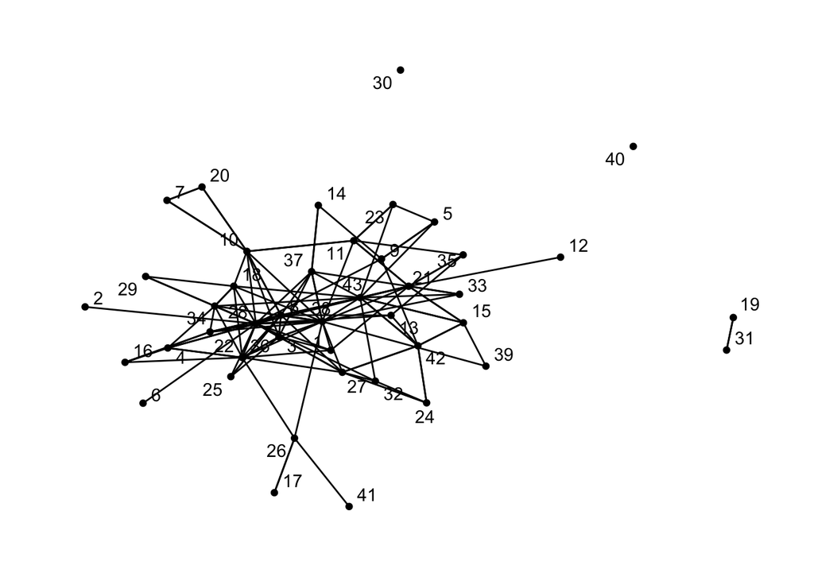

```r
#YOUR CODE HERE
ggraph(leader_measures, layout = "fr") +
  geom_node_point(aes()) +
  geom_node_text(aes(label = ID),
                     repel=TRUE) +
  geom_edge_link() +
  theme_graph()
```

After you are satisfied with your sociogram, answer the following questions?

1. How is the Year 3 confidential exchange network similar to the collaboration network? How is it different?
   - YOUR RESPONSE HERE

### 🧶 Knit & Check ✅

Congrats! You made it to the end of the Explore section and are ready to learn a little ab out modeling network selection processes using ERGMs! Before proceeding further, knit your document and check to see if you encounter any errors.

# 4. MODEL

Recall from Carolan (2014) that **Exponential Random Graph Models** provide a means to compare whether a network’s observed structural properties occur more frequently than you could expect from chance alone. More specifically, ERGMS provide a way to determine whether network properties (e.g., reciprocity) occur by chance as a result of other network properties (e.g., density) or whether the observed properties are unlikely given other parameters in the network.

While the technical aspects of estimating ERGMs are complex, their interpretation is pretty straightforward. In this section we are interested exploring how these models be used make inferences about the social processes at work in the School Leaders data. For example, in this section we will explore the following questions:

- If one school leader turns to another to discuss something confidential, is the latter likely to reciprocate?
- Are school leaders more likely to confide in someone if they both confide in the same school leader?
- Do a leader’s gender and efficacy score, predict a confidential exchange between two leaders?

## 4a. Loading Network Data

As we’ve discovered in this course, network data can come in many different forms — ties can be stored as edgelists or matrices, saved as .csv or excel files, and converted to a variety of network R objects; attributes for the nodes, ties and dyads in can also various forms and added in various ways to objects in R. For the {ergm} package, however, data will need to be transformed into a `network` object — the format that statnet uses to store and work with network data.

Fortunately, we have already prepared our data for quick conversion to a `network` object and can supply just a couple arguments to the `as.network()` function from the {network} package:

- `x =` a matrix giving the network structure in adjacency, incidence, or edgelist form;
- `vertices` = an optional`data.frame` containing the vertex attributes. The first column is assigned to the `"vertex.names"` and additional columns are used to set vertex attributes using their column names.

Similar to the `tbl_graph` function from {tidygraph} that we used above, let’s add our `leader_edges` edge-list and our `leader_nodes` data frame a the `x =` and `vertices =` attributes in the `as.network()` function and assign to a new object called `leader_network`:

```r
leader_network <- as.network(leader_edges,
                             vertices = leader_nodes)

leader_network
```

```
##  Network attributes:
##   vertices = 43
##   directed = TRUE
##   hyper = FALSE
##   loops = FALSE
##   multiple = FALSE
##   bipartite = FALSE
##   total edges= 143
##     missing edges= 0
##     non-missing edges= 143
##
##  Vertex attribute names:
##     DISTRICT/SITE EFFICACY MALE TRUST vertex.names
##
## No edge attributes
```

Note that we could also have supplied our `leader_matrix` as the first argument, but using and edgelist vastly simplifies the process of adding node attributes.

Let’s also check the be sure that our `leader_network` is indeed a `network` object by using the `class()` function to identify object type:

```r
class(leader_network)
```

```
## [1] "network"
```

So far so good! Let’s start building our first ERGM model!

## 4b. Estimate the ERGM Model

We’ll begin by running a simple model both to demonstrate the most commonly used functions for ERGMs and also to replicate the approach in Chapter 9 of Carolan (2014).

The syntax for specifying a model in the `ergm` package follows **R**’s formula convention: `my_network ~ ergm_term_1 + ergm_term_2 + ergm_term_3` and so forth.

This syntax is used for both the `summary` and `ergm` functions.

- The `summary` function simply returns the numerical values of the network statistics in the model.
- The `ergm` function estimates the model with those statistics.

As noted by the [Statnet Development Team](http://statnet.org/Workshops/ergm_tutorial.html#The_summary_and_ergm_functions,_and_supporting_functions):

> It is good practice to run a `summmary` command on any model before fitting it with `ergm`. This is the ERGM equivalent of performing some descriptive analysis on your covariates. This can help you make sure you understand what the term represents, and it can help to flag potential problems that will lead to poor modeling results.

### Network Structure Parameters

Let’s start with with a simple model similar to the P<sub>1</sub> model in Table 9.4. This model contains the ergm-term **`edges`** that represents the total number of edges in the network, and the ergm-term **`mutual`** that examines the tendency for ties to be reciprocated, i.e. “mutuality.”

```r
summary(leader_network ~ edges + mutual)
```

```
##  edges mutual
##    143     36
```

We see from our summary that our `leader_network` consists of 143 edges and 36 reciprocated dyads.

Since the `ergm()` function automatically uses a stochastic MCMC-based estimation algorithm, use the `set.seed()` function and set the value to 589 (note this could be any number besides our course number) so we produce the same results each time.

Now let’s estimate our model, save the results as `ergm_mod_1`, and use the `summary()` function again to take a look at our estimates. Also,

```r
set.seed(589)

ergm_mod_1 <-ergm(leader_network ~ edges + mutual)

summary(ergm_mod_1)
```

```
## Call:
## ergm(formula = leader_network ~ edges + mutual)
##
## Monte Carlo Maximum Likelihood Results:
##
##        Estimate Std. Error MCMC % z value Pr(>|z|)
## edges   -3.1158     0.1269      0  -24.56   <1e-04 ***
## mutual   3.1164     0.3018      0   10.33   <1e-04 ***
## ---
## Signif. codes:  0 '***' 0.001 '**' 0.01 '*' 0.05 '.' 0.1 ' ' 1
##
##      Null Deviance: 2503.6  on 1806  degrees of freedom
##  Residual Deviance:  892.7  on 1804  degrees of freedom
##
## AIC: 896.7  BIC: 907.7  (Smaller is better. MC Std. Err. = 1.307)
```

Since ERGMs predict the presence of a network tie, with estimates indicating the importance of each to the presence of a tie, estimated coefficients can be explained in terms similar to logistic regression. That is, positive significant coefficients indicate that the corresponding parameters in the observed network (e.g. reciprocated ties between school leaders, controlling for all other parameters in the model, occur more than would be expected by chance, thus increasing the likelihood that a tie will occur, and vice-versa for negative coefficients.

After several iterations, we see that our model finally converges and suggest that the estimates for our `edges` and `mutual` terms are statistically significant. The negative estimate for the `edge` paramter, as noted by Carolan (2014), implies that the probability of a confidential exchange tie in year 3 is relatively low. The reciprocity parameter, on the other hand, is 3.11 in our model, and indicates a strong tendency for confidential-exchange ties to be reciprocated.

Now let’s add the an ergm-term for transitivity. Modeling transitivity, or the “friend of a friend” phenomenon in social networks, is both computationally intensive because of the all the possible “triangles” in a directed network, and also very prone to model degeneration, i.e. when models that fail to converge by reaching a value expected by the parameters included in the model.

Ergm-terms for transitivity such as `triangles` and `transitive` in particular are prone to model degeneration. Fortunately, the {ergm} package includes a “more robust way of modeling triangles: the geometrically-weighed edgewise shared partner term (GWESP).”

Let’s add the `gwesp` term to our model with the suggested defaults from the Statnet Tutorial section on [What it looks like when a model fails](http://statnet.org/Workshops/ergm_tutorial.html#What_it_looks_like_when_a_model_fails) and take a look at the summary first:

```r
summary(leader_network ~ edges +
          mutual +
          transitive +
          gwesp(0.25, fixed=T))
```

```
##            edges           mutual       transitive gwesp.fixed.0.25
##         143.0000          36.0000         202.0000         116.2971
```

As you can see, we have 202 transitive triad types.

Now lets run our model including transitivity and take a look at our estimates. Note that this make take a couple minutes to run. If you’d like to watch the number of iterations of the model set `message = TRUE`.

```r
ergm_mod_2 <-ergm(leader_network ~ edges +
                    mutual +
                    gwesp(0.25, fixed=T))

summary(ergm_mod_2)
```

```
## Call:
## ergm(formula = leader_network ~ edges + mutual + gwesp(0.25,
##     fixed = T))
##
## Monte Carlo Maximum Likelihood Results:
##
##                  Estimate Std. Error MCMC % z value Pr(>|z|)
## edges             -3.9749     0.1481      0 -26.832   <1e-04 ***
## mutual             2.2887     0.3237      0   7.071   <1e-04 ***
## gwesp.fixed.0.25   1.0737     0.1308      0   8.209   <1e-04 ***
## ---
## Signif. codes:  0 '***' 0.001 '**' 0.01 '*' 0.05 '.' 0.1 ' ' 1
##
##      Null Deviance: 2503.6  on 1806  degrees of freedom
##  Residual Deviance:  805.5  on 1803  degrees of freedom
##
## AIC: 811.5  BIC: 828  (Smaller is better. MC Std. Err. = 0.6168)
```

Contrary to the analysis in Chapter 9, our model so far suggest that there is a tendency toward transitivity, that is a confidential exchange is likely to occur between two people who both confide in another person.

At this point, however, we have only focused on structural mechanisms inherent to networks themselves, or “global features” of the graph independent of actors, and have not looked at individual attributes among actors that may be shaping out network.

### Actor Attribute Parameters

As noted by Carolan (2014), ERGMs have advanced to the point where actor attributes, or actor-level covariates, can now be incorporated into model estimation, such as individuals’ demographic (e.g., gender) or behavioral (e.g., efficacy) characteristics. These two attributes examined in Chapter 9 with leadership efficacy measured by survey items based on the [Principal Efficacy Scale](https://wmpeople.wm.edu/asset/index/mxtsch/pse).

The attributes were included as both sender and receiver effects, which again can be very computationally intensive and thus timely to run, while sometimes prone to model degeneracy without some model fine tuning.

To simplify this approach, I’ve include these attributes using the `nodefactor()` and `nocov()` ergm-terms respectively which allow us to test whether those who are Male or have higher efficacy scores are more likely to either send or receive at tie.

```r
ergm_3 <- ergm(leader_network ~ edges +
                 mutual +
                 gwesp(0.25, fixed=T) +
                 nodefactor('MALE') +
                 nodecov('EFFICACY')
               )


summary(ergm_3)
```

```
## Call:
## ergm(formula = leader_network ~ edges + mutual + gwesp(0.25,
##     fixed = T) + nodefactor("MALE") + nodecov("EFFICACY"))
##
## Monte Carlo Maximum Likelihood Results:
##
##                   Estimate Std. Error MCMC % z value Pr(>|z|)
## edges             -4.37697    0.41830      0 -10.464   <1e-04 ***
## mutual             2.28225    0.31709      0   7.198   <1e-04 ***
## gwesp.fixed.0.25   1.06029    0.13157      0   8.058   <1e-04 ***
## nodefactor.MALE.1  0.10611    0.06122      0   1.733   0.0831 .
## nodecov.EFFICACY   0.02320    0.02952      0   0.786   0.4318
## ---
## Signif. codes:  0 '***' 0.001 '**' 0.01 '*' 0.05 '.' 0.1 ' ' 1
##
##      Null Deviance: 2503.6  on 1806  degrees of freedom
##  Residual Deviance:  803.8  on 1801  degrees of freedom
##
## AIC: 813.8  BIC: 841.3  (Smaller is better. MC Std. Err. = 0.8549)
```

Although there appears to be a slight, though not statistically significant tendency towards male leaders being more likely to send or recieve ties, the primary drivers of network formation appear to be structural features of the network including reciprocity and transitivity.

Sadly, we were not able to replicated the findings from Carolan (2014), but we did not replicate the model exactly, nor did we fine tune our model parameters. Regardless, this provided a practical exercise for demonstrating ergm models.

### **👉 Your Turn** **⤵**

Before moving on to checking the goodness of fit for our final model, try testing a new model by modifying or adding your own ergm-term. For example, to test for homophily among gender, the `ergm()` function includes a `nodematch()` argument that could be used to see if school leaders are more likely to confide in colleagues of their own gender.

You can look at a [table of common ergm-terms](http://statnet.org/nme/d2-ergmterms.html) or type “ergm-terms” into the help menu of the files pane for some suggested examples.

```r
#YOUR CODE HERE
ergm_4 <- ergm(leader_network ~ edges +
                 mutual +
                 gwesp(0.25, fixed=T) +
                 nodematch('MALE') +
                 nodecov('EFFICACY')
               )


summary(ergm_4)
```

```
## Call:
## ergm(formula = leader_network ~ edges + mutual + gwesp(0.25,
##     fixed = T) + nodematch("MALE") + nodecov("EFFICACY"))
##
## Monte Carlo Maximum Likelihood Results:
##
##                  Estimate Std. Error MCMC % z value Pr(>|z|)
## edges            -4.17867    0.41466      0 -10.077   <1e-04 ***
## mutual            2.29951    0.31860      0   7.218   <1e-04 ***
## gwesp.fixed.0.25  1.06948    0.12806      0   8.351   <1e-04 ***
## nodematch.MALE   -0.14375    0.15742      0  -0.913    0.361
## nodecov.EFFICACY  0.02061    0.02840      0   0.726    0.468
## ---
## Signif. codes:  0 '***' 0.001 '**' 0.01 '*' 0.05 '.' 0.1 ' ' 1
##
##      Null Deviance: 2504  on 1806  degrees of freedom
##  Residual Deviance:  805  on 1801  degrees of freedom
##
## AIC: 815  BIC: 842.5  (Smaller is better. MC Std. Err. = 0.7012)
```

Once you’ve checked the summary of your model estimates, write your interpretation of the results below:

- YOUR RESPONSE HERE

## 4c. Check Model Fit

One test of whether an ergm model is a “good fit” fo the data is “how well it reproduces the observed global network properties *that are not in the model*.” This can be accomplished by choosing a network statistic that is not in the model, and comparing the value of this statistic observed in the original network to the distribution of values we get in simulated networks from our model, using the `gof()` function to test the goodness-of-fit.

### The GOF Function

The `gof()` function is a bit different than the `summary()` and `ergm()` functions, in that it only takes 3 ergm-terms as arguments: degree, esp (edgwise share partners), and distance (geodesic distances). Each of these terms captures an aggregate network distribution, at either the node level (degree), the edge level (esp), or the dyad level (distance).

Let’s go ahead and run the `gof()` function on our `ergm_3` model and plot the results:

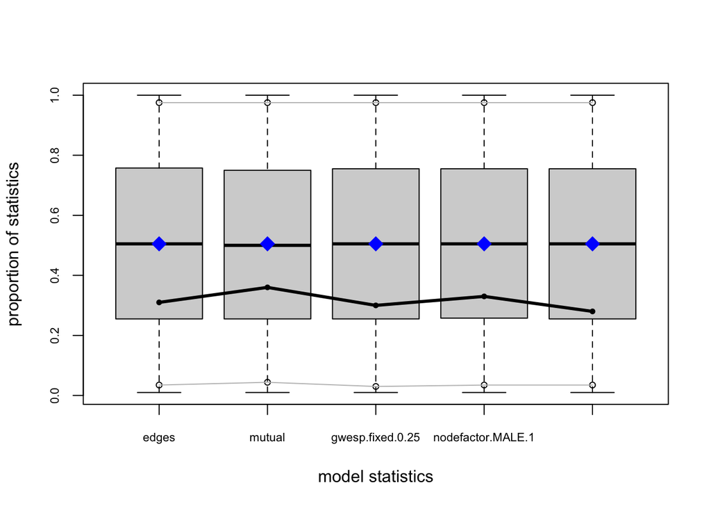

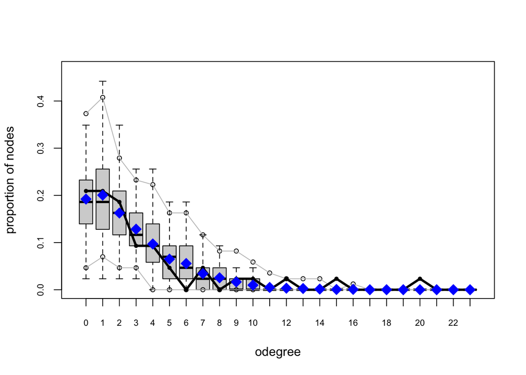

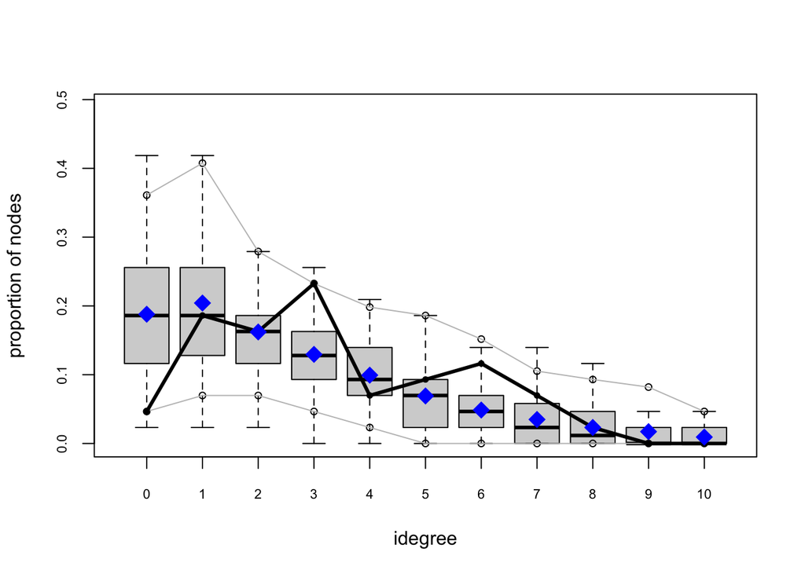

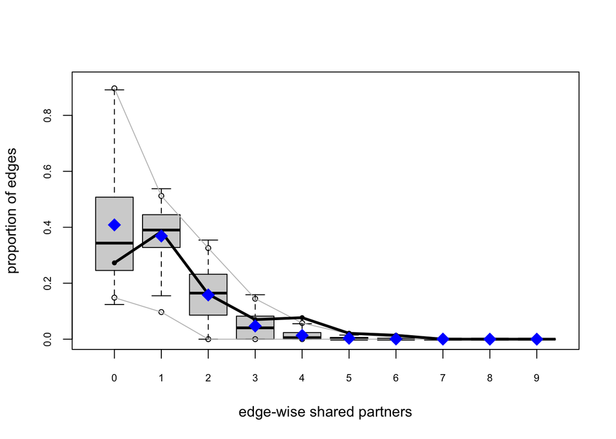

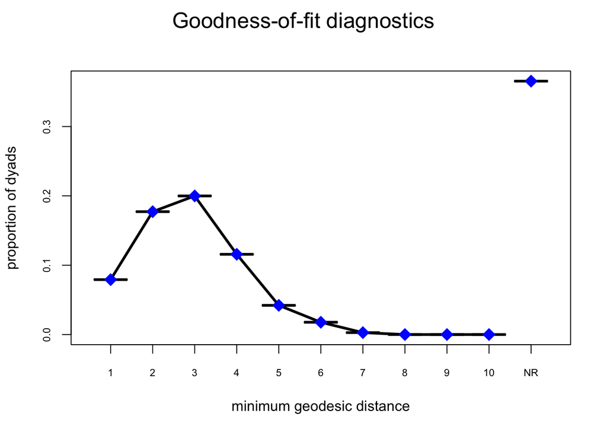

```r
ergm_3_gof <- gof(ergm_3)

plot(ergm_3_gof)
```

Overall, the model appears to fit reasonably well in that black line in our charts (the actual observed network measures) closely follows the aggregate measures generated from the simulations, or permutations of our network.

### Check MCNC Diagnostics

One final check on our model is to examine the Monte-Carlo Markov Chain (MCMC) diagnostics to make sure our model is not heading of in the wrong direction and likely to never produce a network similar to what was observed, which is referred to as “model degeneracy.” As the statnet authors note:

> When a model is not a good representation of the observed network, the simulated networks produced in the MCMC chains may be far enough away from the observed network that the estimation process is affected. In the worst case scenario, the simulated networks will be so different that the algorithm fails altogether.

Let run the `mcmc.diagnostics()` function on our final model anyways and check the results:

```r
mcmc.diagnostics(ergm_3)
```

```
## Sample statistics summary:
##
## Iterations = 8757248:17506304
## Thinning interval = 8192
## Number of chains = 1
## Sample size per chain = 1069
##
## 1. Empirical mean and standard deviation for each variable,
##    plus standard error of the mean:
##
##                     Mean     SD Naive SE Time-series SE
## edges              5.453  48.53   1.4843          3.507
## mutual             1.642  15.93   0.4872          1.174
## gwesp.fixed.0.25   6.460  60.34   1.8456          4.324
## nodefactor.MALE.1  4.468  54.95   1.6807          3.853
## nodecov.EFFICACY  74.178 657.79  20.1187         47.696
##
## 2. Quantiles for each variable:
##
##                      2.5%     25%    50%    75%  97.5%
## edges               -85.3  -27.00  5.000  40.00  102.0
## mutual              -28.0   -9.00  2.000  13.00   34.3
## gwesp.fixed.0.25    -99.3  -35.14  3.557  49.56  131.6
## nodefactor.MALE.1  -102.0  -32.00  7.000  44.00  113.0
## nodecov.EFFICACY  -1157.5 -365.96 83.910 549.09 1368.6
##
##
## Are sample statistics significantly different from observed?
##                edges    mutual gwesp.fixed.0.25 nodefactor.MALE.1
## diff.      5.4527596 1.6417212         6.459675         4.4677268
## test stat. 1.5547614 1.3985883         1.493876         1.1596610
## P-val.     0.1200029 0.1619365         0.135208         0.2461868
##            nodecov.EFFICACY Overall (Chi^2)
## diff.            74.1779981              NA
## test stat.        1.5552319      9.60664980
## P-val.            0.1198909      0.09098437
##
## Sample statistics cross-correlations:
##                       edges    mutual gwesp.fixed.0.25 nodefactor.MALE.1
## edges             1.0000000 0.9761986        0.9901966         0.9536128
```

[output cut: 30 more lines]

```
##
## Fraction in 1st window = 0.1
## Fraction in 2nd window = 0.5
##
##             edges            mutual  gwesp.fixed.0.25 nodefactor.MALE.1
##            -2.278            -2.109            -2.147            -2.393
##  nodecov.EFFICACY
##            -2.280
##
## Individual P-values (lower = worse):
##             edges            mutual  gwesp.fixed.0.25 nodefactor.MALE.1
##        0.02272463        0.03498748        0.03176601        0.01670546
##  nodecov.EFFICACY
##        0.02263627
## Joint P-value (lower = worse):  0.2535035 .
```

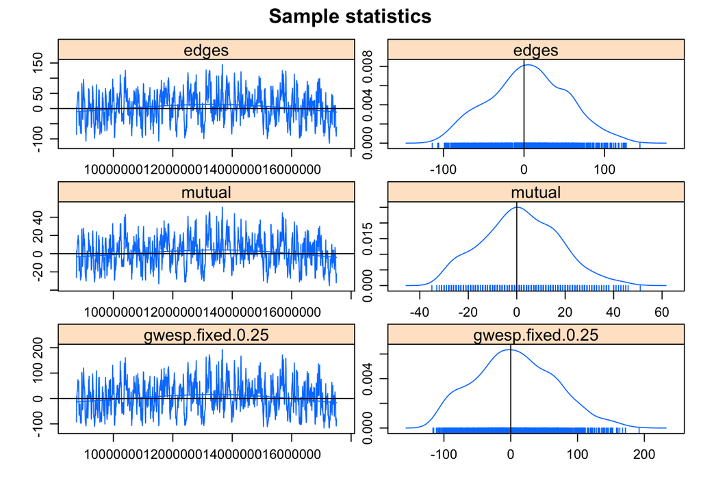

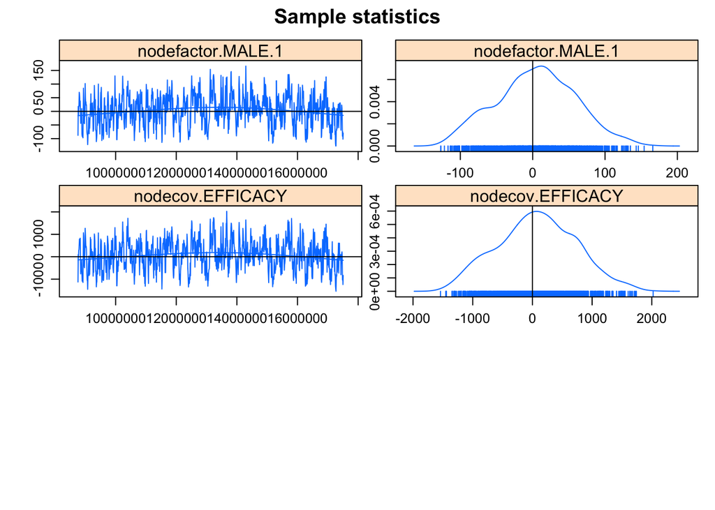

[output not shown]

One simple heuristic for interpreting `mcmc.diagnostics()` results is too look for “balance.” The charts with all the squiggles, to use a non-technical term, should have a scale that ideally is centered on 0 and have roughly straight line running through it, while the chart that looks like a simple line graph should also be ideally centered at 0 and roughly normally distributed on both ends. Overall, the diagnostics indicate there is room for improvement but nothing is wildly off and hence our model did not fail to converge.

### **👉 Your Turn** **⤵**

Use the code chunk below to check the model fit and diagnostics for the model the you created in 4b. Estimate the ERGM Model:

```r
#YOUR CODE HERE
```

# 5. COMMUNICATE

For your Independent Analysis assignment for Unit 3 next week, you’ll create either a simple report or slide deck using an R Markdown document just like this to share out some key findings from your analysis. Regardless of whether you plan to talk us through your analysis and findings with a presentation or walk us through with a brief written report, your presentation or report should address the following questions:

1. **Purpose**. What question or questions are guiding your analysis? What did you hope to learn by answering these questions and why should your audience care about your findings?
2. **Methods**. What data did you selected for analysis? What steps did you take took to prepare your data for analysis and what techniques you used to analyze your data? These should be fairly explicit with your embedded code.
3. **Findings**. What did you ultimately find? How do your “data products” help to illustrate these findings? What conclusions can you draw from your analysis?
4. **Discussion**. What were some of the strengths and weaknesses of your analysis? How might your audience use this information? How might you revisit or improve upon this analysis in the future?

### **👉 Your Turn** **⤵**

Now that you’ve become more familiar with this dataset and the social network perspective, what other aspects of this dataset, or a dataset you are interested in exploring, could you investigate using the approaches demonstrated in Chapter 9?

- YOUR RESPONSE HERE

What specific research questions might you ask that would be helpful for being understanding and improving learning, or the context in which the data is collected?

- YOUR RESPONSE HERE

### 🧶 Knit & Check ✅

Congrats! You’ve finished the Unit 3 Guided Walkthrough and are ready for your independent analysis next week!

To complete this assignment, knit your document and send me an email at sbkellog@ncsu.edu letting me know you’re all set.

Carolan, Brian. 2014. “Social Network Analysis and Education: Theory, Methods & Applications.” https://doi.org/10.4135/9781452270104.

Pavel N. Krivitsky, Mark S. Handcock, David R. Hunter, Carter T. Butts, Chad Klumb, Steven M. Goodreau, and Martina Morris. 2003-2020. *Statnet: Software Tools for the Statistical Modeling of Network Data*. Statnet Development Team. http://statnet.org.

Thomas, Andrew C, and Joseph K Blitzstein. 2011. “Valued Ties Tell Fewer Lies: Why Not to Dichotomize Network Edges with Thresholds.” *arXiv Preprint arXiv:1101.0788*.